# Electronics and Telecommunication

We want to build a model that can help the company predict the signal quality using various parameters

Let's now do the steps to finally build a model using Neural Nets

### Import libraries

```python
import numpy as np
import pandas as pd
import matplotlib.pyplot as plt
%matplotlib inline
import seaborn as sns

import warnings
warnings.filterwarnings('ignore')
import os
```

### Import data

Let's first import the data from google drive

```python
from google.colab import drive
drive.mount('/content/drive')
```

```python
os.chdir('/content/drive/My Drive/NN')
os.getcwd()
```

```
'/content/drive/My Drive/NN'
```

```python
signal_data = pd.read_csv('Part- 1 - Signal.csv')
```

Let' look at a sample of data

```python
signal_data.head()
```

|  | Parameter 1 | Parameter 2 | Parameter 3 | Parameter 4 | Parameter 5 | Parameter 6 | Parameter 7 | Parameter 8 | Parameter 9 | Parameter 10 | Parameter 11 | Signal_Strength |
| --- | --- | --- | --- | --- | --- | --- | --- | --- | --- | --- | --- | --- |
| 0 | 7.4 | 0.70 | 0.00 | 1.9 | 0.076 | 11.0 | 34.0 | 0.9978 | 3.51 | 0.56 | 9.4 | 5 |
| 1 | 7.8 | 0.88 | 0.00 | 2.6 | 0.098 | 25.0 | 67.0 | 0.9968 | 3.20 | 0.68 | 9.8 | 5 |
| 2 | 7.8 | 0.76 | 0.04 | 2.3 | 0.092 | 15.0 | 54.0 | 0.9970 | 3.26 | 0.65 | 9.8 | 5 |
| 3 | 11.2 | 0.28 | 0.56 | 1.9 | 0.075 | 17.0 | 60.0 | 0.9980 | 3.16 | 0.58 | 9.8 | 6 |
| 4 | 7.4 | 0.70 | 0.00 | 1.9 | 0.076 | 11.0 | 34.0 | 0.9978 | 3.51 | 0.56 | 9.4 | 5 |

We can see that we have signal strength variable and that seems to be dependant on 11 parameters

Let's now look at the shape of the data

```python
signal_data.shape
```

```
(1599, 12)
```

So we have 11 predictors and 1 predicted variable

```python
print(signal_data['Signal_Strength'].max())
print(signal_data['Signal_Strength'].min())
```

```
8
3
```

Signal strength varies from 3 to 8

### Data analysis & visualisation

Let's perform a detailed statistical analysis on the data

```python
signal_data.describe().transpose()
```

|  | count | mean | std | min | 25% | 50% | 75% | max |
| --- | --- | --- | --- | --- | --- | --- | --- | --- |
| Parameter 1 | 1599.0 | 8.319637 | 1.741096 | 4.60000 | 7.1000 | 7.90000 | 9.200000 | 15.90000 |
| Parameter 2 | 1599.0 | 0.527821 | 0.179060 | 0.12000 | 0.3900 | 0.52000 | 0.640000 | 1.58000 |
| Parameter 3 | 1599.0 | 0.270976 | 0.194801 | 0.00000 | 0.0900 | 0.26000 | 0.420000 | 1.00000 |
| Parameter 4 | 1599.0 | 2.538806 | 1.409928 | 0.90000 | 1.9000 | 2.20000 | 2.600000 | 15.50000 |
| Parameter 5 | 1599.0 | 0.087467 | 0.047065 | 0.01200 | 0.0700 | 0.07900 | 0.090000 | 0.61100 |
| Parameter 6 | 1599.0 | 15.874922 | 10.460157 | 1.00000 | 7.0000 | 14.00000 | 21.000000 | 72.00000 |
| Parameter 7 | 1599.0 | 46.467792 | 32.895324 | 6.00000 | 22.0000 | 38.00000 | 62.000000 | 289.00000 |
| Parameter 8 | 1599.0 | 0.996747 | 0.001887 | 0.99007 | 0.9956 | 0.99675 | 0.997835 | 1.00369 |
| Parameter 9 | 1599.0 | 3.311113 | 0.154386 | 2.74000 | 3.2100 | 3.31000 | 3.400000 | 4.01000 |
| Parameter 10 | 1599.0 | 0.658149 | 0.169507 | 0.33000 | 0.5500 | 0.62000 | 0.730000 | 2.00000 |
| Parameter 11 | 1599.0 | 10.422983 | 1.065668 | 8.40000 | 9.5000 | 10.20000 | 11.100000 | 14.90000 |
| Signal_Strength | 1599.0 | 5.636023 | 0.807569 | 3.00000 | 5.0000 | 6.00000 | 6.000000 | 8.00000 |

From the output we can see all the important statistics like mean, median, standard deviation, 25th percentile, 75th percentile, minimum and maximum

Signal_Strength is the target variable

Let's now perform a detailed univariate, bivariate and multivariable analyses

Univariate

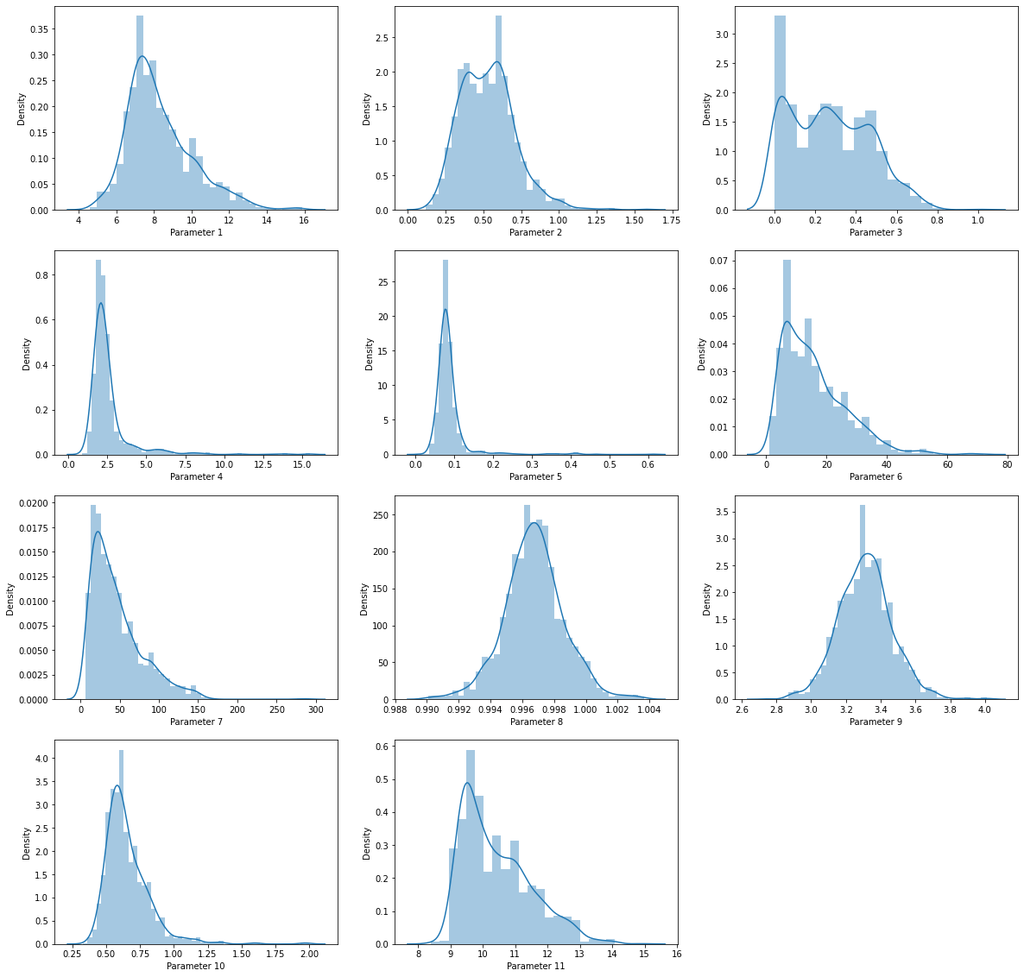

```python
plt.figure(figsize=(20,20))

plt.subplot(4,3,1)
sns.distplot(signal_data['Parameter 1']);

plt.subplot(4,3,2)
sns.distplot(signal_data['Parameter 2']);

plt.subplot(4,3,3)
sns.distplot(signal_data['Parameter 3']);

plt.subplot(4,3,4)
sns.distplot(signal_data['Parameter 4']);

plt.subplot(4,3,5)
sns.distplot(signal_data['Parameter 5']);

plt.subplot(4,3,6)
sns.distplot(signal_data['Parameter 6']);

plt.subplot(4,3,7)
sns.distplot(signal_data['Parameter 7']);

plt.subplot(4,3,8)
sns.distplot(signal_data['Parameter 8']);

plt.subplot(4,3,9)
sns.distplot(signal_data['Parameter 9']);

plt.subplot(4,3,10)
sns.distplot(signal_data['Parameter 10']);

plt.subplot(4,3,11)
sns.distplot(signal_data['Parameter 11']);
```

From the above plots, it is evident that most of them are not symmetrical. Parameters 6, 7 and 11 are clearly showing signs of deviation from symmetry. Parameter 2 is bimodal and Parameter 3 is trimodal

Bivariate

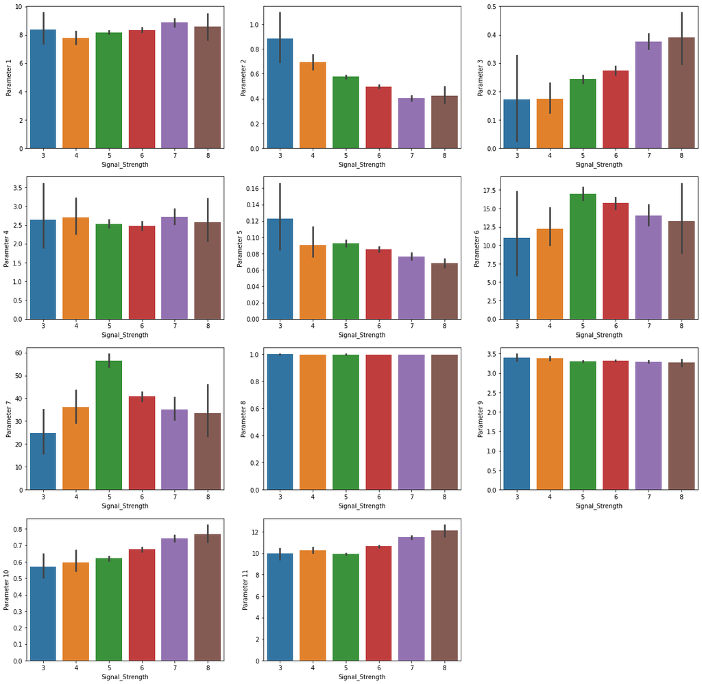

```python
plt.figure(figsize=(20,20))

plt.subplot(4,3,1)
sns.barplot('Signal_Strength','Parameter 1',data=signal_data);

plt.subplot(4,3,2)
sns.barplot('Signal_Strength','Parameter 2',data=signal_data);

plt.subplot(4,3,3)
sns.barplot('Signal_Strength','Parameter 3',data=signal_data);

plt.subplot(4,3,4)
sns.barplot('Signal_Strength','Parameter 4',data=signal_data);

plt.subplot(4,3,5)
sns.barplot('Signal_Strength','Parameter 5',data=signal_data);

plt.subplot(4,3,6)
sns.barplot('Signal_Strength','Parameter 6',data=signal_data);

plt.subplot(4,3,7)
sns.barplot('Signal_Strength','Parameter 7',data=signal_data);

plt.subplot(4,3,8)
sns.barplot('Signal_Strength','Parameter 8',data=signal_data);

plt.subplot(4,3,9)
sns.barplot('Signal_Strength','Parameter 9',data=signal_data);

plt.subplot(4,3,10)
sns.barplot('Signal_Strength','Parameter 10',data=signal_data);

plt.subplot(4,3,11)
sns.barplot('Signal_Strength','Parameter 11',data=signal_data);
```

We can see that parameters vary across signal strength for most of the parameters. It is only parameter 8 and probably parameter 9 that are constant across signal strength. Overall, the general parameters seem to be good predictors for signal strength

Multivariate

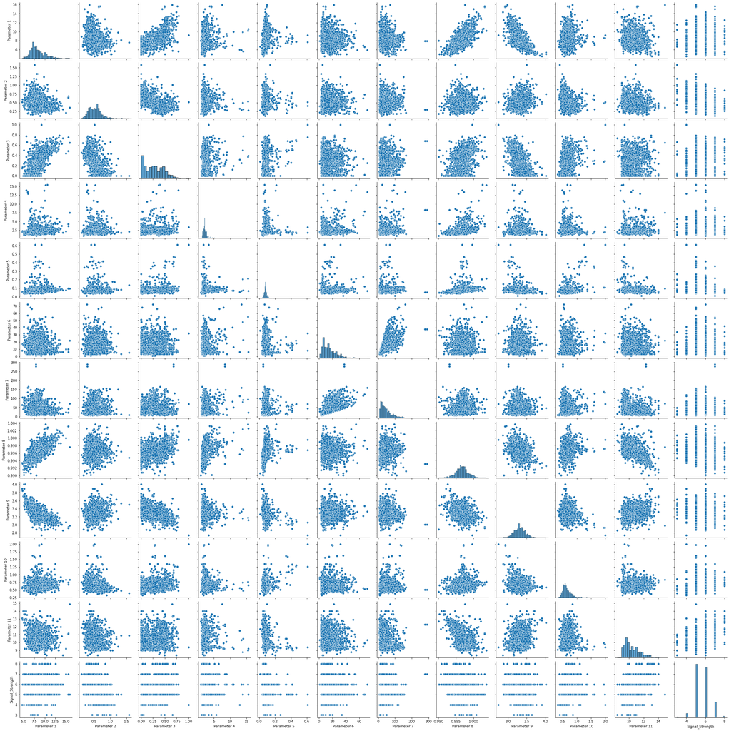

```python
sns.pairplot(signal_data);
```

We can see from the above graph that some of the variables are correlated with each other. There are some violations in our assumptions

### Design, train, tune and test a neural network regressor

Let's now split the input data into train and test and standardize the datasets before feeding them into a neural network

```python
import tensorflow
from sklearn.preprocessing import MinMaxScaler
from sklearn.model_selection import train_test_split
```

```python
X = signal_data.drop('Signal_Strength',axis=1)
y = signal_data['Signal_Strength']
```

```python
X_train, X_test, y_train, y_test = train_test_split(X, y, test_size=0.33, random_state=42)
```

Let's now normalize the data

```python
scale = MinMaxScaler()
```

```python
print(X_train.max())
print(X_train.min())
```

```
Parameter 1      15.90000
Parameter 2       1.33000
Parameter 3       1.00000
Parameter 4      15.50000
Parameter 5       0.61100
Parameter 6      68.00000
Parameter 7     289.00000
Parameter 8       1.00369
Parameter 9       4.01000
Parameter 10      2.00000
Parameter 11     14.90000
dtype: float64
Parameter 1     4.60000
Parameter 2     0.12000
Parameter 3     0.00000
Parameter 4     0.90000
Parameter 5     0.01200
Parameter 6     1.00000
Parameter 7     6.00000
Parameter 8     0.99007
Parameter 9     2.74000
Parameter 10    0.37000
Parameter 11    8.40000
dtype: float64
```

We can see that the minimum and maximum values vary very much for the different parameters

Let's standardize them

```python
X_train = scale.fit_transform(X_train)
X_test = scale.fit_transform(X_test)
```

```python
print(X_train.max())
print(X_train.min())
```

```
1.0000000000000002
0.0
```

We can see that the minimum and maximum values are 0 and 1

Let's now design a neural network

```python
from tensorflow.keras.models import Sequential
from tensorflow.keras.layers import Dense
```

Sigmoid

```python
model = Sequential()
model.add(Dense(6,input_shape=(11,),activation='sigmoid'))
model.add(Dense(1,activation='linear'))
```

```python
model.compile(loss='mean_squared_error',optimizer='adam',metrics=['mean_squared_error'])
```

```python
model.fit(X_train,y_train,batch_size=32,validation_data=(X_test,y_test),epochs=250)
```

```
<keras.callbacks.History at 0x7fe8dad0e510>
```

Relu

```python
model = Sequential()
model.add(Dense(6,input_shape=(11,),activation='relu'))
model.add(Dense(1,activation='linear'))
```

```python
model.compile(loss='mean_squared_error',optimizer='adam',metrics=['mean_squared_error'])
```

```python
model.fit(X_train,y_train,batch_size=32,validation_data=(X_test,y_test),epochs=250)
```

```
<keras.callbacks.History at 0x7fe8d7ac88d0>
```

Let's now evaluate the performance. We will go ahead with RELU

```python
model.evaluate(x=X_test, y=y_test, batch_size=32, verbose=1)
```

```
[0.44565582275390625, 0.44565582275390625]
```

We can see that the mean squared error is 0.4457

Let's predict the outputs on the test set

```python
y_predict = model.predict(X_test)
```

We will now stack the true signal strength and predicted signal strength of the test data side by side

```python
Compare = pd.DataFrame(y_test.reset_index(drop=True)).join(pd.DataFrame([i[0] for i in y_predict]))
Compare.columns = ["Signal_Strength","Signal_Strength_Predict"]
```

```python
Compare
```

|  | Signal_Strength | Signal_Strength_Predict |
| --- | --- | --- |
| 0 | 6 | 5.354218 |
| 1 | 5 | 5.216897 |
| 2 | 6 | 5.742073 |
| 3 | 5 | 5.474080 |
| 4 | 6 | 5.839074 |
| ... | ... | ... |
| 523 | 4 | 6.198062 |
| 524 | 7 | 6.910771 |
| 525 | 7 | 6.780120 |
| 526 | 5 | 5.297733 |
| 527 | 5 | 5.177049 |

528 rows × 2 columns

We will now compare the average values of the predictions to the true strength values

```python
Compare.groupby('Signal_Strength').mean()['Signal_Strength_Predict']
```

```
Signal_Strength
3    5.168915
4    5.584748
5    5.435088
6    5.836744
7    6.296827
8    6.684886
Name: Signal_Strength_Predict, dtype: float64
```

In the above table, the true signal strengths are on the left and the predicted signal strengths are on the right

We can see that the mean predicted signal strength shows a gradual increase as the true signal strength increases from 3 to 8 with the exception of 4 and 5 where it dipped a bit. Let's look at the counts of the signal strengths to see if that can explain the deviation

```python
y_train.value_counts()
```

```
5    464
6    425
7    129
4     34
8     11
3      8
Name: Signal_Strength, dtype: int64
```

We can see that the values are highly unbalanced. 5 and 6 are represented much higher than others and 4, 8 and 3 are very few. So we can expect that the outputs will be more centered around 5 and 6 and that explains the deviation we saw from the previous output

Let's now look at a scatter plot between signal strength and signal strength predict

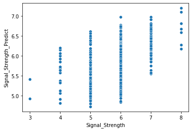

```python
sns.scatterplot('Signal_Strength','Signal_Strength_Predict',data=Compare);
```

We can see that there is an increasing trend in the above graph which is in line with our expectations. The predicted Signal Strength values are showing an increasing trend with respect to the actual Signal Strength values. We can see that the points are spread across a lot and we can expect a more closely clustered set of predicions provided we have a more balanced input

### Pickle the model for future use

We will now save the model for future use

```python
from keras.models import load_model
model.save('/content/drive/My Drive/NN/et_pickle.h5')
```

Deep learning models are too large and may not be pickled using pickle. We used HDF5 for storing the huge file

# Autonomous Vehicles

We will build a digit classifier on the street view housing number dataset

### Import the data

Let's now import the input data

```python
import h5py
```

```python
 f1 = h5py.File('Part - 4 - Autonomous_Vehicles_SVHN_single_grey1.h5')
```

### Data pre-processing and visualisation

Let's look at the contents of the dataset

```python
list(f1)
```

```
['X_test', 'X_train', 'X_val', 'y_test', 'y_train', 'y_val']
```

```python
X_train = np.array(f1['X_train'])
y_train = np.array(f1['y_train'])
X_val = np.array(f1['X_val'])
y_val = np.array(f1['y_val'])
X_test = np.array(f1['X_test'])
y_test = np.array(f1['y_test'])
```

Let's look at the shapes of the components we saw above

```python
print(X_train.shape)
print(y_train.shape)
print(X_val.shape)
print(y_val.shape)
print(X_test.shape)
print(y_test.shape)
```

```
(42000, 32, 32)
(42000,)
(60000, 32, 32)
(60000,)
(18000, 32, 32)
(18000,)
```

We can see that train data has 42000 records, val data has 60000 records and test data has 18000 records

Let's now look at output

```python
f1['y_train'][:]
```

```
array([2, 6, 7, ..., 7, 0, 4], dtype=uint8)
```

We will visualize a sample output using matplotlib

```
Label : 7
```

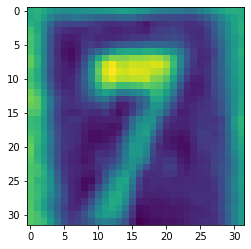

```python
print("Label : {}".format(f1['y_train'][2]))
plt.imshow(f1['X_train'][2]);
```

We can see that the above image is 7 and the label is also 7. We can see that the image is not very clear. This makes it challenging for us to create a model to predict it correctly

### Reshape

Let's reshape the data so that it can be fed into a network

```python
X_train = X_train.reshape(42000,1024)
X_val = X_val.reshape(60000,1024)
X_test = X_test.reshape(18000,1024)
```

Let's look at the maximum values of train, val and test datasets

```python
print(X_train.max())
print(X_val.max())
print(X_test.max())
```

```
254.9745
254.9745
254.9745
```

Let's now look at the minimum values of train,val and test datasets

```python
print(X_train.min())
print(X_val.min())
print(X_test.min())
```

```
0.0
0.0
0.0
```

### Normalize

We will now normalize the data by dividing by 254.9745

```python
print(X_train.max())
print(X_train.min())

X_train = X_train / 254.9745
X_val = X_val / 254.9745
X_test = X_test / 254.9745

print(X_train.max())
print(X_train.min())
```

```
254.9745
0.0
1.0
0.0
```

We can see from the outputs that the data has been normalized

### One Hot Encode

We will now one hot encode the class variable

```python
print(y_train.max())
print(y_train.min())
```

```
9
0
```

We can see that there are a total of 10 classes starting at 0 and ending at 9

```python
print(y_train[10])
y_train = tensorflow.keras.utils.to_categorical(y_train,num_classes=10)
y_val = tensorflow.keras.utils.to_categorical(y_val,num_classes=10)
y_test = tensorflow.keras.utils.to_categorical(y_test,num_classes=10)
print(y_train[10])
```

```
1
[0. 1. 0. 0. 0. 0. 0. 0. 0. 0.]
```

We have converted the output to categorical

We will see some other images and their labels

```
Label is: 2
Label is: 6
Label is: 7
Label is: 4
Label is: 4
Label is: 0
Label is: 3
Label is: 0
Label is: 7
Label is: 3
```

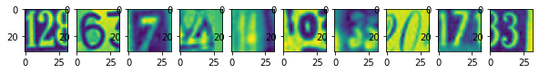

```python
plt.figure(figsize=(10,1))

for i in range(10):
  plt.subplot(1,10,i+1)
  plt.imshow(X_train[i].reshape(32,32))
  print('Label is:', np.argmax(y_train[i]))
```

We can see that the label corresponds to the central digit in each of the images

### Design, train, tune and test a neural network image classifier

Let's start building the model now

```python
from tensorflow.keras.models import Sequential
from tensorflow.keras.layers import Dense
from tensorflow.keras import regularizers,optimizers
```

We will create a function so that it can be run multiple times so as to tune it to give best performance. We will only use kernel regularizer. We will use other regularization techniques in a later iteration

```python
def tune_model(iterations,lr,Lambda):

  iterations = iterations
  learning_rate = lr
  hidden_nodes = 256
  output_nodes = 10

  model = Sequential()
  model.add(Dense(hidden_nodes,input_shape=(1024,),activation='relu'))
  model.add(Dense(output_nodes,activation='softmax',kernel_regularizer=regularizers.l2(Lambda)))

  adam = optimizers.Adam(learning_rate=learning_rate)

  model.compile(loss='categorical_crossentropy',optimizer=adam,metrics=['accuracy'])

  model.fit(X_train,y_train,epochs=iterations,validation_data=(X_val,y_val),batch_size=1000)

  score = model.evaluate(X_train,y_train,verbose=0)

  return score
```

Now let's check if the loss is reasonable

```python
lr=0.00001
Lambda=0
tune_model(1,lr,Lambda)
```

```
[2.308669328689575, 0.09671428799629211]
```

The accuracy of around 10% seems reasonable

We will now increase the Lambda value and then check what will happen to the loss

```python
lr=0.00001
Lambda=1e3
tune_model(1,lr,Lambda)
```

```
[18323.69140625, 0.1103571429848671]
```

The loss has gone up which is good

Now let's start with some random learning rate and lambda values

```python
lr=1e-7
Lambda=1e-7
tune_model(20,lr,Lambda)
```

```
[2.469867706298828, 0.10592857003211975]
```

The learning rate seems too low. Let's now try with a higher learning rate

```python
lr=1e7
Lambda=1e-7
tune_model(20,lr,Lambda)
```

```
[440941641728.0, 0.09971428662538528]
```

Even this is not good. Let's reduce it a bit and retry

```python
lr=1e0
Lambda=1e-7
tune_model(20,lr,Lambda)
```

```
[2.3171725273132324, 0.09971428662538528]
```

Since this also has not helped let's now search for learning rate values between 1e-7 and 1e0

Let's now run 10 iterations for different values to scout for the values that give the best accuracies. Let's loop only for 10 times each in order to save time

```python
import math
for k in range(1,10):
  learning_rate = math.pow(10,np.random.uniform(-7,0))
  Lambda = math.pow(10,np.random.uniform(-8,-2))
  acc = tune_model(10,learning_rate,Lambda)
  print("The parameters for the {} iteration are {} and {}".format(k,learning_rate,Lambda))
```

```
The parameters for the 1 iteration are 3.0469898684658912e-05 and 0.0033341476073449486
The parameters for the 2 iteration are 9.247241916156776e-05 and 1.591445526282589e-05
The parameters for the 3 iteration are 6.103851403332725e-07 and 0.00031483074537041116
The parameters for the 4 iteration are 0.02721033734007981 and 0.0006697886254575555
The parameters for the 5 iteration are 0.002248137947726754 and 1.0015921939711626e-07
The parameters for the 6 iteration are 0.0005244331947406066 and 1.4720198871425298e-08
The parameters for the 7 iteration are 0.024183774976604934 and 8.036845430195908e-06
The parameters for the 8 iteration are 6.073301449460744e-05 and 0.00021215951609112008
The parameters for the 9 iteration are 0.597789539395993 and 1.2919612710712591e-08
```

Let's now narrow down the search from 1e-7 to 1e-3

```python
import math
for k in range(1,21):
  learning_rate = math.pow(10,np.random.uniform(-7,-3))
  Lambda = math.pow(10,np.random.uniform(-8,-3))
  acc = tune_model(10,learning_rate,Lambda)
  print("The parameters for the {} iteration are {} and {}".format(k,learning_rate,Lambda))
```

```
The parameters for the 1 iteration are 0.00018091598868844632 and 0.0002713436575403946
The parameters for the 2 iteration are 7.749682029902103e-05 and 2.7700613681852304e-06
The parameters for the 3 iteration are 1.1556574611565317e-06 and 0.000319957306578635
The parameters for the 4 iteration are 3.1922473131808097e-07 and 8.978528746263458e-07
The parameters for the 5 iteration are 1.3655349720513276e-05 and 5.546134124248673e-06
The parameters for the 6 iteration are 6.650414214291143e-06 and 7.89693363021124e-06
The parameters for the 7 iteration are 1.0538431781277183e-06 and 7.885079770316584e-07
The parameters for the 8 iteration are 7.531656871203757e-06 and 2.0053081247226253e-06
The parameters for the 9 iteration are 1.0753410144084467e-06 and 5.335226002325123e-06
The parameters for the 10 iteration are 3.282458945130286e-05 and 1.1242785495187975e-06
The parameters for the 11 iteration are 2.3382660044259075e-07 and 1.772356691842566e-08
The parameters for the 12 iteration are 1.4569218426586489e-07 and 5.597123587464219e-06
The parameters for the 13 iteration are 0.00027357822796103147 and 1.3447520920803959e-07
The parameters for the 14 iteration are 2.7118339075354115e-05 and 0.00010793289736844437
The parameters for the 15 iteration are 2.1619431038392117e-07 and 9.301090666092236e-07
The parameters for the 16 iteration are 2.7210933482560577e-06 and 3.1701835262267216e-05
The parameters for the 17 iteration are 0.0005142086304466909 and 1.18988841561622e-08
The parameters for the 18 iteration are 2.007411387967343e-06 and 3.9812794129572285e-08
The parameters for the 19 iteration are 1.624461163632886e-06 and 3.490908762123867e-08
The parameters for the 20 iteration are 1.3747954765344189e-05 and 2.8178726686322835e-06
```

Let's now run 100 iterations at these values

```python
learning_rate = 0.0005142086304466909
Lambda = 1.18988841561622e-08
tune_model(100,learning_rate,Lambda)
```

```
[0.5742429494857788, 0.8361904621124268]
```

Final Model

```python
iterations = 100
learning_rate = 0.0005142086304466909
Lambda = 1.18988841561622e-08
hidden_nodes = 256
output_nodes = 10

model = Sequential()
model.add(Dense(hidden_nodes,input_shape=(1024,),activation='relu'))
model.add(Dense(output_nodes,activation='softmax',kernel_regularizer=regularizers.l2(Lambda)))

adam = optimizers.Adam(learning_rate=learning_rate)

model.compile(loss='categorical_crossentropy',optimizer=adam,metrics=['accuracy'])

history = model.fit(X_train,y_train,epochs=iterations,validation_data=(X_val,y_val),batch_size=1000)
```

Let's plot loss vs epochs for training and validation datasets

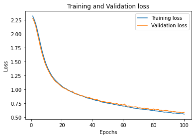

```python
loss_train = history.history['loss']
loss_val = history.history['val_loss']
epochs = range(1,101)
plt.plot(epochs,loss_train,label='Training loss')
plt.plot(epochs,loss_val,label='Validation loss')
plt.title('Training and Validation loss')
plt.xlabel('Epochs')
plt.ylabel('Loss')
plt.legend()
plt.show()
```

We can see that training loss is slightly lower than validation loss at 100 epochs. The difference is very small and doesn't indicate overfitting

```python
for k in history.history.keys():
  print(k)
```

```
loss
accuracy
val_loss
val_accuracy
```

Let's plot accuracy vs epochs for training and validation datasets

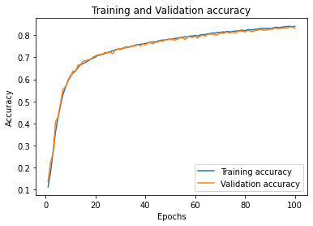

```python
acc_train = history.history['accuracy']
acc_val = history.history['val_accuracy']
epochs = range(1,101)
plt.plot(epochs,acc_train,label='Training accuracy')
plt.plot(epochs,acc_val,label='Validation accuracy')
plt.title('Training and Validation accuracy')
plt.xlabel('Epochs')
plt.ylabel('Accuracy')
plt.legend()
plt.show()
```

The accuracy of training dataset is very slightly greater than that of validation data. Just like we have seen before, here too the difference is very small to indicate any overfit. The model seems to generalize well

Let's now do the final part of predicting on the test dataset

```python
y_predict = model.predict(X_test)
```

```python
y_predict.argmax(axis=1)
```

```
array([0, 7, 2, ..., 7, 9, 2])
```

```python
y_test.argmax(axis=1)
```

```
array([1, 7, 2, ..., 7, 9, 2])
```

Let's now calculate some metrics to evaluate how the model performed

```python
from sklearn.metrics import accuracy_score,confusion_matrix,classification_report
```

```python
print(accuracy_score(y_predict.argmax(axis=1),y_test.argmax(axis=1)))
```

```
0.8121666666666667
```

The overall accuracy of almost 81.22% is slightly less than the accuracy of 84.05% on train and 83.2% on val indicating slight overfitting but it is not very high to warrant our serious attention

Let's now look at confusion matrix and classification report

```python
print(confusion_matrix(y_predict.argmax(axis=1),y_test.argmax(axis=1)))
```

```
[[1630   40   27   34   42   44   89   36   84  123]
 [  37 1557   42   54   52   33   33   85   67   56]
 [   6   16 1480   30   29   13   18   62   35   33]
 [  28   49   49 1337   20   99   28   32   66   57]
 [  28   74   52   38 1579   37   88   25   63   39]
 [  11   14   18  141   20 1444   69   12   69   56]
 [  20   18    7   15   22   42 1450    8  103   13]
 [  15   39   74   33   13   11   11 1517   15   29]
 [   9    7   14   10    6   18   28    6 1250   23]
 [  30   14   40   27   29   27   18   25   60 1375]]
```

```python
print(classification_report(y_predict.argmax(axis=1),y_test.argmax(axis=1)))
```

```
              precision    recall  f1-score   support

           0       0.90      0.76      0.82      2149
           1       0.85      0.77      0.81      2016
           2       0.82      0.86      0.84      1722
           3       0.78      0.76      0.77      1765
           4       0.87      0.78      0.82      2023
           5       0.82      0.78      0.80      1854
           6       0.79      0.85      0.82      1698
           7       0.84      0.86      0.85      1757
           8       0.69      0.91      0.79      1371
           9       0.76      0.84      0.80      1645

    accuracy                           0.81     18000
   macro avg       0.81      0.82      0.81     18000
weighted avg       0.82      0.81      0.81     18000
```

The precision, recall and f1-score all seem to be doing good

Let's now apply batch normalization and dropout to see if that can improve the results over what l2 regulatization provided. Let's also include an additional layer

```python
from tensorflow.keras.layers import BatchNormalization, Dropout
```

```python
def tune_model_regularization(iterations,lr):

  iterations = iterations
  learning_rate = lr
  hidden_nodes = 256
  output_nodes = 10

  model = Sequential()
  model.add(Dense(hidden_nodes,input_shape=(1024,),activation='relu'))
  model.add(BatchNormalization())
  model.add(Dropout(0.2))
  model.add(Dense(hidden_nodes,activation='relu'))
  model.add(BatchNormalization())
  model.add(Dropout(0.2))
  model.add(Dense(output_nodes,activation='softmax'))

  adam = optimizers.Adam(learning_rate=learning_rate)

  model.compile(loss='categorical_crossentropy',optimizer=adam,metrics=['accuracy'])

  model.fit(X_train,y_train,epochs=iterations,validation_data=(X_val,y_val),batch_size=1000)

  score = model.evaluate(X_train,y_train,verbose=0)

  return score
```

Let's now implement the same things we did above

```python
import math
for k in range(1,21):
  learning_rate = math.pow(10,np.random.uniform(-7,-3))
  acc = tune_model_regularization(10,learning_rate)
  print("The learning rate for the {} iteration is {}".format(k,learning_rate))
```

```
The learning rate for the 1 iteration is 0.0002496140058012844
The learning rate for the 2 iteration is 9.58650126747577e-06
The learning rate for the 3 iteration is 9.05088168462746e-06
The learning rate for the 4 iteration is 2.0669503392970898e-05
The learning rate for the 5 iteration is 0.00012107844099701547
The learning rate for the 6 iteration is 0.0003915461454648631
The learning rate for the 7 iteration is 2.9029210388628224e-05
The learning rate for the 8 iteration is 2.1048687431314214e-07
The learning rate for the 9 iteration is 1.2825035167332815e-05
The learning rate for the 10 iteration is 2.9046217268236494e-07
The learning rate for the 11 iteration is 2.0310781119681467e-07
The learning rate for the 12 iteration is 7.838972628082575e-06
The learning rate for the 13 iteration is 2.2616966698860926e-05
The learning rate for the 14 iteration is 3.5348055727236974e-05
The learning rate for the 15 iteration is 3.5073427560316138e-06
The learning rate for the 16 iteration is 2.4463046026877303e-05
The learning rate for the 17 iteration is 4.1901029007105715e-06
The learning rate for the 18 iteration is 0.00027403486397488625
The learning rate for the 19 iteration is 9.467777215424476e-07
The learning rate for the 20 iteration is 5.484810121998906e-06
```

Let's now train for a hundred epochs

```python
learning_rate = 0.0003915461454648631
tune_model_regularization(100,learning_rate)
```

```
[0.38487693667411804, 0.8808809518814087]
```

Let's now build the final model

```python
iterations = 100
learning_rate = 0.0003915461454648631
hidden_nodes = 256
output_nodes = 10

model = Sequential()
model.add(Dense(hidden_nodes,input_shape=(1024,),activation='relu'))
model.add(BatchNormalization())
model.add(Dropout(0.2))
model.add(Dense(hidden_nodes,activation='relu'))
model.add(BatchNormalization())
model.add(Dropout(0.2))
model.add(Dense(output_nodes,activation='softmax'))

adam = optimizers.Adam(learning_rate=learning_rate)

model.compile(loss='categorical_crossentropy',optimizer=adam,metrics=['accuracy'])

history = model.fit(X_train,y_train,epochs=iterations,validation_data=(X_val,y_val),batch_size=1000)
```

Let's now plot loss vs epochs for both training and validation datasets

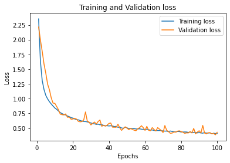

```python
loss_train = history.history['loss']
loss_val = history.history['val_loss']
epochs = range(1,101)
plt.plot(epochs,loss_train,label='Training loss')
plt.plot(epochs,loss_val,label='Validation loss')
plt.title('Training and Validation loss')
plt.xlabel('Epochs')
plt.ylabel('Loss')
plt.legend()
plt.show()
```

We can see that the loss of validation dataset is showing a high variance. Its values are oscillating around those of the training dataset

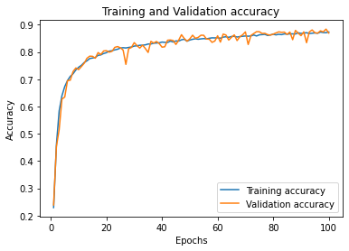

```python
acc_train = history.history['accuracy']
acc_val = history.history['val_accuracy']
epochs = range(1,101)
plt.plot(epochs,acc_train,label='Training accuracy')
plt.plot(epochs,acc_val,label='Validation accuracy')
plt.title('Training and Validation accuracy')
plt.xlabel('Epochs')
plt.ylabel('Accuracy')
plt.legend()
plt.show()
```

We can see the same variance here as well

Let's predict on the test set

```python
y_predict = model.predict(X_test)
```

```python
print(accuracy_score(y_predict.argmax(axis=1),y_test.argmax(axis=1)))
```

```
0.8359444444444445
```

The accuracy is 83.6% which is an imporovement over what we saw before

```python
print(confusion_matrix(y_predict.argmax(axis=1),y_test.argmax(axis=1)))
```

```
[[1624   34   22   15   27   17   62   18   38   51]
 [  47 1623   50   68   93   23   31   75   74   42]
 [   3    4 1455   23   19    9   11   13   21   18]
 [  20   32   52 1336   17   91   27   24   79   36]
 [  16   39   24   24 1569   21   45    8   22   22]
 [   2    7   14   92   15 1462   66    5   49   40]
 [  15   13    3   14   15   49 1494   10   53    8]
 [  34   39  102   51   21   19   19 1627   17   34]
 [   8   12   18   27    6   17   48    7 1339   35]
 [  45   25   63   69   30   60   29   21  120 1518]]
```

```python
print(classification_report(y_predict.argmax(axis=1),y_test.argmax(axis=1)))
```

```
              precision    recall  f1-score   support

           0       0.90      0.85      0.87      1908
           1       0.89      0.76      0.82      2126
           2       0.81      0.92      0.86      1576
           3       0.78      0.78      0.78      1714
           4       0.87      0.88      0.87      1790
           5       0.83      0.83      0.83      1752
           6       0.82      0.89      0.85      1674
           7       0.90      0.83      0.86      1963
           8       0.74      0.88      0.80      1517
           9       0.84      0.77      0.80      1980

    accuracy                           0.84     18000
   macro avg       0.84      0.84      0.84     18000
weighted avg       0.84      0.84      0.84     18000
```

From the above results, we can see that the second model produced better accuracy but on the flipside the variance increased a bit. If accuracy is of the utmost importance for us, we can go ahead with model 2 but if stability also is needed, then perhaps we can go ahead with model 1.